- Analysis sections
- Bertin
- Biplot
- Test

Report generated: Sat Sep 21 15:29:57 2013

More info ▼

The Bertin display

One of the most popular ways of displaying grid data has been adopted from Bertin's (1974) graphical proposals, which have had an immense influence onto data visualization. One of the most appealing ideas presented by Bertin is the concept of the reordable matrix. It is comprised of graphical displays for each cell, allowing to identify structures by eye-balling reordered versions of the data matrix (see Bertin, 1974). In the context of repertory grids, the display is made up of a simple colored rectangle where the color denotes the corresponding score. Bright values correspond to low, dark to high scores. For an example of how to analyze a Bertin display see e.g. Dick (2000) and Raeithel (1998).

Literature

- Bertin, J. (1974). Graphische Semiologie: Diagramme, Netze, Karten. Berlin, New York: de Gruyter.
- Dick, M. (2000). The Use of Narrative Grid Interviews in Psychological Mobility Research. Forum Qualitative Sozialforschung / Forum: Qualitative Social Research, 1(2).
- Raeithel, A. (1998). Kooperative Modellproduktion von Professionellen und Klienten - erlauetert am Beispiel des Repertory Grid. Selbstorganisation, Kooperation, Zeichenprozess: Arbeiten zu einer kulturwissenschaftlichen, anwendungsbezogenen Psychologie (pp. 209-254). Opladen: Westdeutscher Verlag.

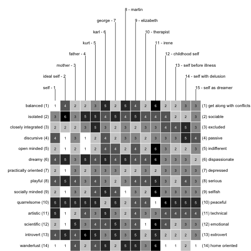

More info ▼

The Biplot

Literature

- Gabriel, K. (1971). The biplot graphic display of matrices with application to principal component analysis. Biometrika, 58(3), 453–467.
- Greenacre, M. (2010). Biplots in practice. Madrid: BBVA Foundation. Retrieved from http://www.multivariatestatistics.org/biplots.html
- Slater, P. (1977). The measurement of intrapersonal space by grid technique: Dimensions of intrapersonal space (Vol. 2). London: Wiley & Sons.

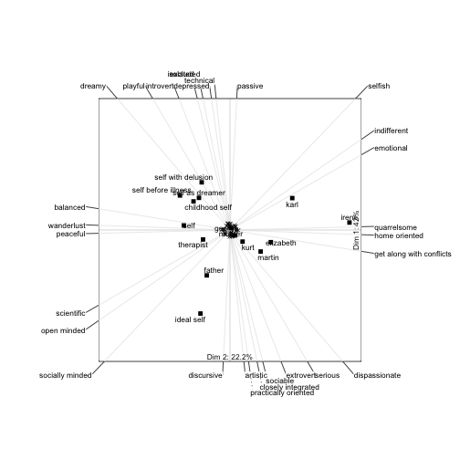

Testing

```
##
## ##############################
## Correlation between constructs
## ##############################
##
## Type of correlation:  pearson
##
##                              1     2     3     4     5     6     7     8     9    10    11    12
## balanced - get along     1      0.26  0.00  0.09  0.53  0.60 -0.35  0.35  0.36 -0.84 -0.24  0.33
## isolated - sociable      2           -0.35 -0.77  0.03  0.57 -0.52  0.24 -0.09 -0.07 -0.42  0.06
## closely in - excluded    3                  0.25 -0.14 -0.26  0.48 -0.12  0.20  0.13  0.22 -0.02
## discursive - passive     4                        0.30 -0.42  0.40 -0.06  0.28 -0.15  0.55  0.16
## open minde - indifferen  5                              0.25  0.14  0.04  0.82 -0.58  0.24  0.72
## dreamy - dispassion      6                                   -0.63  0.36  0.15 -0.70 -0.24  0.14
## practicall - depressed   7                                         -0.52  0.41  0.22  0.38  0.26
## playful - serious        8                                                0.00 -0.22 -0.36 -0.04
## socially m - selfish     9                                                     -0.40  0.33  0.76
## quarrelsom - peaceful   10                                                            0.06 -0.32
## artistic - technical    11                                                                  0.04
## scientific - emotional  12
## introvert - extrovert   13
## wanderlust - home orien 14
##                            13    14
## balanced - get along     0.15  0.72
## isolated - sociable      0.70  0.20
## closely in - excluded   -0.44 -0.07
## discursive - passive    -0.57  0.06
## open minde - indifferen  0.10  0.54
## dreamy - dispassion      0.53  0.55
## practicall - depressed  -0.55 -0.06
## playful - serious        0.29  0.31
## socially m - selfish     0.11  0.46
## quarrelsom - peaceful   -0.07 -0.81
## artistic - technical    -0.25 -0.15
## scientific - emotional   0.33  0.56
## introvert - extrovert          0.24
## wanderlust - home orien
```